# Statistické testy pro relativní četnost

Klíčové pojmy:

- test pro porovnání jednoho/dvou relativních četností
- rozptyl relativní četnosti
- směrodatná chyba relativní četnosti
- rozdíl relativních četností

Doposud jsme se zabývali statistickými testy, které se používají na porovnání jednoho/dvou výběrových průměrů. V tomto cvičení si ukážeme, jaké statistické testy můžeme použít pro porovnání výběrových relativních četností.

### Test pro jednu relativní četnost

Výběrová relativní četnost $\hat{P}_n$ approximuje normální rozložení $\hat{P}_n \sim N(p, \frac{p(1-p)}{n})$ , pokud platí, že $n\hat{p} > 10$ a zároveň $n(1-\hat{p})>10$. To znamená, že můžeme aplikovat vlastnosti centrální limitní věty. Pojďme si tuto skutečnost ukázat.

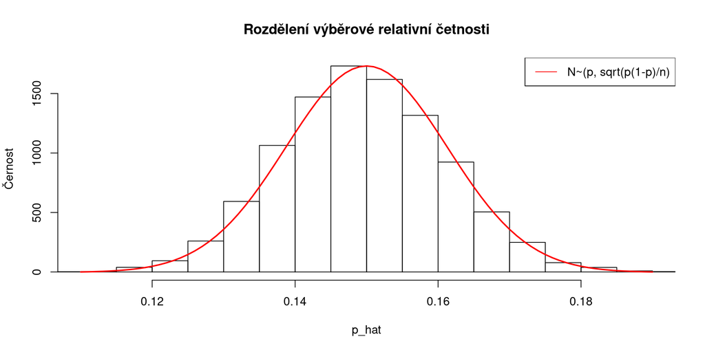

```r
# populacni relativni cetnost
p <- 0.15
n <- 1000
# opakujme 10 000x vybery o velikosti 1000 z teto populace
n_p_hat <- rbinom(n=10000, size = n, prob = p)

hist(n_p_hat/n,
     xlab = "p_hat",
     ylab = "Černost",
     main = "Rozdělení výběrové relativní četnosti",
     xlim = c(0.11, 0.19))

x <- seq(0.11,0.19,by=0.001)
pdf <- dnorm(x, mean = p, sd = sqrt(p*(1-p) / n))
# nova osa
par(new = TRUE)
plot(x,
     pdf,
     xlab = "", ylab = "", main = "",
     bty = "n", axes = FALSE,
     type = "l",
     col = "red",
     lwd = 2)

legend("topright", legend = c("N~(p, sqrt(p(1-p)/n)"), col = "red", lty = 1)
```

Pojďme se ještě podívat, jaké výběrové rozdělení můžeme čekat, pokud $n\hat{p} < 10$.

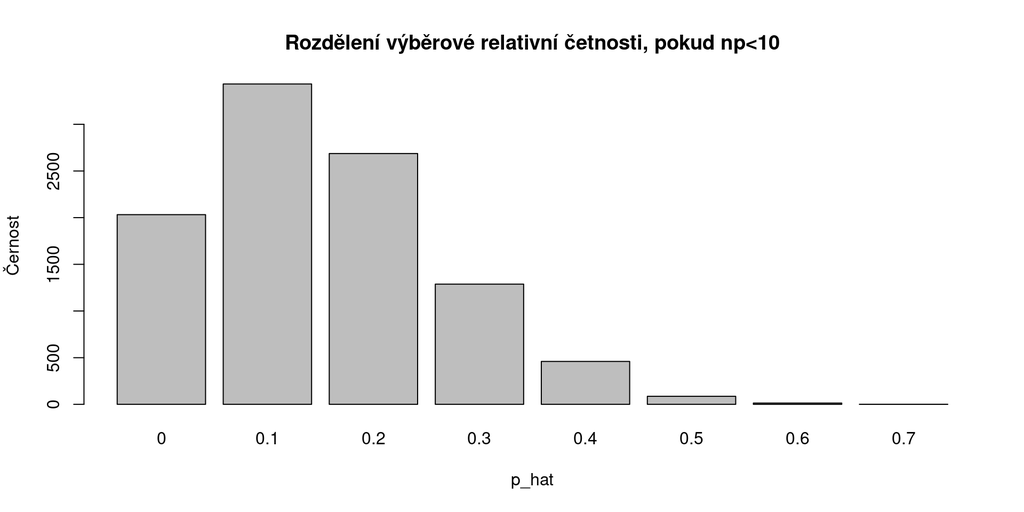

```r
# populacni relativni cetnost
p <- 0.15
n <- 10
# opakujme 10 000x vybery o velikosti 1000 z teto populace
n_p_hat <- rbinom(n=10000, size = n, prob = p)

barplot(table(n_p_hat/n),
     xlab = "p_hat",
     ylab = "Černost",
     main = "Rozdělení výběrové relativní četnosti, pokud np<10")
```

Teď když víme, za jakých podmínek můžeme očekávat, že výběrové rozdělení bude normálně rozděleno a jaký tvar bude rozložení mít, si můžeme ukázat jak vypočítat t-test pro relativní četnost. Testovací statistiku vypočítáme jako $t=\frac{\hat{p}-p_o}{\sqrt{\frac{p_{0}(1-p_{0})}{n}}}$. Všimněte si, že tento vzorec je opět stejný jako u jiných testů $testovaci\;statistika=\frac{bodovy\;odhad-nulova\;hypoteza}{smerodatna\;chyba}$. Pojďme si ukázat příklad.

Podle smlouvy může dodavatel zaslat nejvýše 5% zmetků. Z dodávky 20000 výrobků jste náhodně vybrali 500 výrobků a našli jste 30 zmetků. Zjistěte, zda je pravděpodobné, že dodavatelská firma porušila smlouvu.

$H_0: p \le 0.05$

$H_1: p > 0.05$

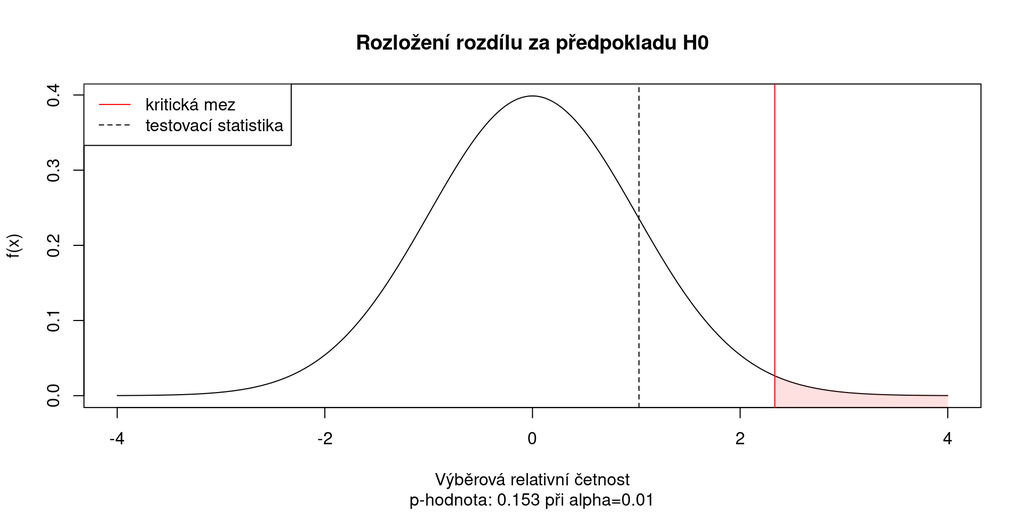

```r
p_0 <- 0.05
k <- 30
n <- 500
p_hat <- k/n
s_v <- n-1
alpha <- 0.01

standardni_chyba <- sqrt(p_0*(1-p_0) / n)
t <- (p_hat - p_0) / standardni_chyba
kriticka_mez <- qt(1-alpha, df = s_v)

x <- seq(-4,4,by = 0.001)
pdf <- dt(x, df = s_v)
p <- 1-pt(t, df = s_v)

plot(x, pdf,
     xlab = "Výběrová relativní četnost", ylab = "f(x)",
     main = "Rozložení rozdílu za předpokladu H0",
     sub = paste0("p-hodnota: ", round(p, 3), " při alpha=", alpha),
     type = "l")
abline(v = kriticka_mez, col = "red")
# oblast zamitnuti H0
for(i in c(1:length(x))) {
  if(x[i] > kriticka_mez) {
    lines(c(x[i], x[i]), c(-1, pdf[i]),
          col = adjustcolor("red", alpha.f = 0.01))
  }
}
abline(v = t, lty = 2)
legend("topleft",
       c("kritická mez", "testovací statistika"),
       col = c("red", "black"),
       lty = c(1,2))
```

Interval spolehlivosti poté můžeme vypočítat jako

```r
p_hat + qt(c(alpha/2, 1-alpha/2), df = s_v) * standardni_chyba
```

```
## [1] 0.03479754 0.08520246
```

### Test pro porovnání dvou relativních četností

Stejně jako u dvojvýběrového testu pro průměr, používáme tento test, pokud chceme porovnat relativní četnost pro 2 skupiny. Předpokládáme, že tyto skupiny jsou nezávislé. Testovací statistiku vypočítáme jako $t = \frac{(\hat{p_1}-\hat{p_2}) - (p_1-p_2)}{s_{(\hat{p_1} - \hat{p_2})}}$, kde směrodatná chyba rozdílu $s_{(\hat{p_1} - \hat{p_2})}$ se vypočítá jako $s_{(\hat{p_1} - \hat{p_2})} = \sqrt{\frac{\hat{p_1}(1-\hat{p_1})}{n_1} + \frac{\hat{p_2}(1-\hat{p_2})}{n_2}}$. Pojďme si ukázat na následujícím příkladu. Společnost testuje 2 verze reklam pomocí A/B testing. Návštěvníkům webu se náhodně zobrazí jedna z reklamy. První reklama má click-through rate (% návštěvníků webu, kteří klikli na reklamu) 2%. Druhá reklama má click-through rate 2.8%. Stránky s první verzí reklamy navštívilo 4300 zákazníků. Stránky s druhou verzí reklamy navštívilo 4700 zákazníků. Zjistěte, zda existuje dost dat k tomu, abychom řekli, které reklama je lepší.

$H_0: \hat{p_1} = \hat{p_2}$

$H_1: \hat{p_1} \ne \hat{p_2}$

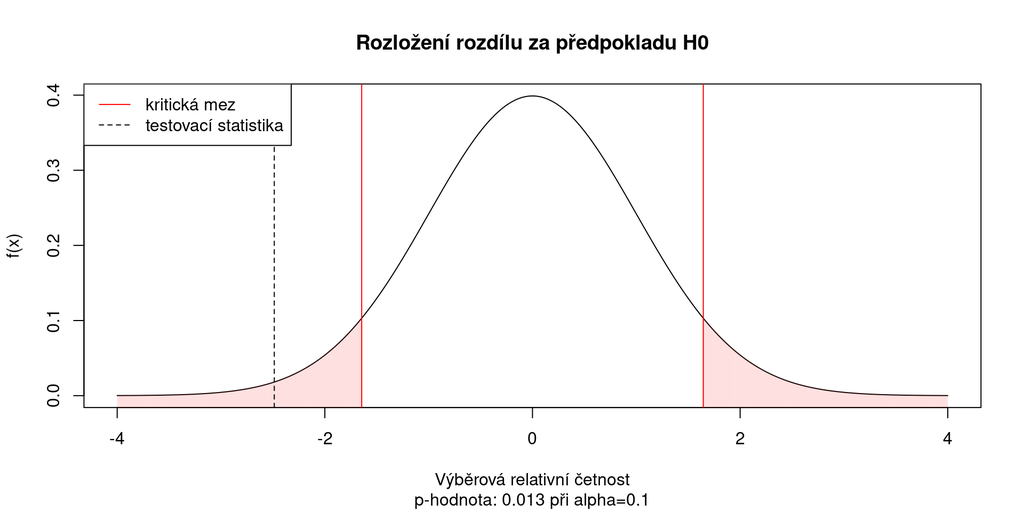

```r
p_hat_1 <- 0.02
p_hat_2 <- 0.028
n_1 <- 4300
n_2 <- 4700
s_v <- n_1 + n_2 - 2
alpha <- 0.1

var_1 <- p_hat_1 * (1-p_hat_1)
var_2 <- p_hat_2 * (1-p_hat_2)
standardni_chyba <- sqrt(var_1/n_1 + var_2/n_2)

t <- (p_hat_1 - p_hat_2) / standardni_chyba
kriticka_mez <- qt(c(alpha/2, 1-alpha/2), df = s_v)

x <- seq(-4,4,by = 0.001)
pdf <- dt(x, df = s_v)
p <- (1-pt(abs(t), df = s_v)) * 2

plot(x, pdf,
     xlab = "Výběrová relativní četnost", ylab = "f(x)",
     main = "Rozložení rozdílu za předpokladu H0",
     sub = paste0("p-hodnota: ", round(p, 3), " při alpha=", alpha),
     type = "l")
abline(v = kriticka_mez, col = "red")
# oblast zamitnuti H0
for(i in c(1:length(x))) {
  if(x[i] > kriticka_mez[2] | x[i] < kriticka_mez[1]) {
    lines(c(x[i], x[i]), c(-1, pdf[i]),
          col = adjustcolor("red", alpha.f = 0.01))
  }
}
abline(v = t, lty = 2)
legend("topleft",
       c("kritická mez", "testovací statistika"),
       col = c("red", "black"),
       lty = c(1,2))
```

Interval spolehlivosti rozdílu.

```r
p_d <- p_hat_1 - p_hat_2
is <- p_d + kriticka_mez * standardni_chyba
print(paste0("Interval spolehlivosti na hladině spolehlivosti ", 1-alpha, " je: ", paste0(round(is, 3), collapse = " až ")))
```

```
## [1] "Interval spolehlivosti na hladině spolehlivosti 0.9 je: -0.013 až -0.003"
```